# Bayesian models of the line bisection task

## Background

- The line bisection task was adopted to test visual neglect given the assumption that the more the patient neglect the left side, the more rightward they will perceive the left endpoint (and hence the larger rightward errors they will make).
- However, this simple “directional bisection error” measure fails to explain many phenomena, including 1) the low validity with other tasks (Sperber & Karnath, 2016); 2) the cross-over effect (Marshall & Halligan, 1989).
- It is possible that the left-neglect patients do not perceive the left-endpoint as rightward, but they cannot perceive a precise left endpoint at all.
- This new assumption is supported by McIntosh et al. (2005), who showed that left-neglect patients were more sensitive to the manipulation on the right endpoint than the left endpoint.
- We can form this idea of “perception uncertainty” more formally under the Bayesian framework.

## Bayesian decision maker

We assume that both patients and healthy people finish the line bisection task as a rational Bayesian decision maker (or say Bayesian reasoner?). However, they have different levels of uncertainty in perceiving the left endpoint, which leads to the performance difference.

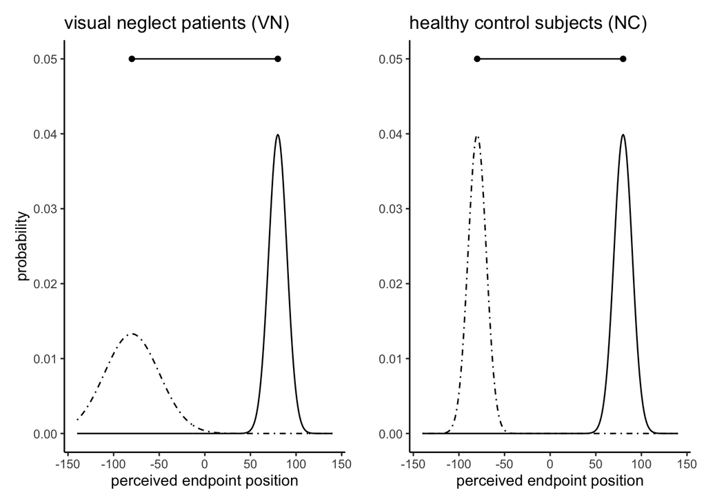

A Bayesian decision maker will make the line bisection decision given

- $\sigma_L$: the variance of perceiving the left endpoint.
- $\sigma_R$: the variance of perceiving the right endpoint.
- $\sigma_C$: the motor variance when drawing the center.
- $\alpha$, $\beta$: a prior about the (half) line length (mean: $\alpha/\beta$, variance: $\alpha/(\beta)^2$).

Meanwhile, it assumes

- the mean of perceiving the left endpoint equals the true left endpoint $y_L$.
- the mean of perceiving the right endpoint equals the true right endpoint $y_R$.
- the mean of motor bias equals 0.

According to a Bayesian decision maker, the parameters above would satisfy that

$c_k \sim \mathcal{N} (0, \sigma_C)$

$l \sim \mathcal{\gamma}(\alpha,\beta)$

$y_{L_k} \sim \mathcal{N}(c_k-l, \sigma_L)$

$y_{R_k} \sim \mathcal{N}(c_k+l, \sigma_R)$

In the human dataset, we have the true endpoints $y_L$, $y_R$ and the answer $c$. Our task is to utilise those information to reverse engineer the hidden parameters. We anticipate that visual neglect patients’ $\sigma_L$ should be larger than the healthy control.

## Parameters

The table below summarised the parameters we have reverse engineered given each participant’s answers. We also calculate the EWB and EWS.

(Note that we here scale the answer so that 80mm = 1 unit.)

|  | sub | cls | sigL | sigR | sigC | alpha | beta | line_prior | line_var | LEW | REW | EWB | EWS |
| --- | --- | --- | --- | --- | --- | --- | --- | --- | --- | --- | --- | --- | --- |
| 1 | NC01 | NC | 0.04 | 0.03 | 0.18 | 18.95 | 25.43 | 0.75 | 0.03 | 0.48 | 0.5 | 0.01 | 0.98 |
| 2 | NC02 | NC | 0.02 | 0.05 | 0.18 | 20.78 | 28.25 | 0.74 | 0.03 | 0.53 | 0.45 | -0.08 | 0.98 |
| 3 | NC03 | NC | 0.1 | 0.03 | 0.19 | 20.5 | 28.53 | 0.72 | 0.03 | 0.46 | 0.54 | 0.08 | 1 |
| 4 | NC04 | NC | 0.02 | 0.08 | 0.17 | 22.29 | 29.92 | 0.74 | 0.02 | 0.5 | 0.4 | -0.11 | 0.9 |
| 5 | NC05 | NC | 0.06 | 0.03 | 0.2 | 20.75 | 27.28 | 0.76 | 0.03 | 0.5 | 0.54 | 0.04 | 1.05 |
| 6 | NC06 | NC | 0.05 | 0.04 | 0.18 | 19.39 | 25.8 | 0.75 | 0.03 | 0.48 | 0.5 | 0.03 | 0.98 |
| 7 | NC07 | NC | 0.03 | 0.02 | 0.2 | 19.03 | 25.48 | 0.75 | 0.03 | 0.52 | 0.54 | 0.02 | 1.06 |
| 8 | NC08 | NC | 0.02 | 0.05 | 0.17 | 20.04 | 26.78 | 0.75 | 0.03 | 0.49 | 0.44 | -0.05 | 0.93 |
| 9 | NC09 | NC | 0.04 | 0.09 | 0.18 | 19.85 | 27.56 | 0.72 | 0.03 | 0.5 | 0.45 | -0.05 | 0.95 |
| 10 | NC10 | NC | 0.04 | 0.16 | 0.19 | 23.61 | 34.1 | 0.69 | 0.02 | 0.54 | 0.4 | -0.14 | 0.93 |

[output cut: 62 more lines]

## Recaps of EWB findings

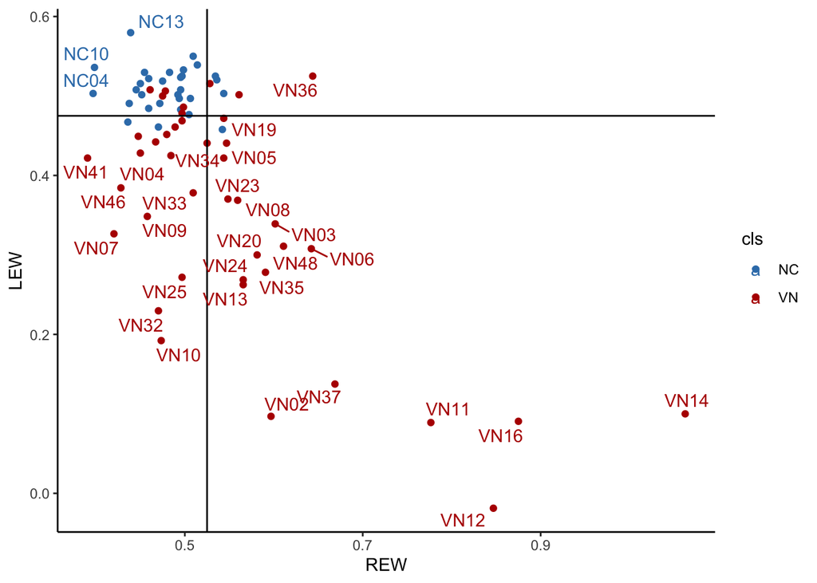

```
[1] "threshold for LEW: 0.4 ; accuracy: 0.722"
[1] "threshold for LEW: 0.425 ; accuracy: 0.75"
[1] "threshold for LEW: 0.45 ; accuracy: 0.833"
[1] "threshold for LEW: 0.475 ; accuracy: 0.847"
[1] "threshold for LEW: 0.5 ; accuracy: 0.778"
[1] "threshold for LEW: 0.525 ; accuracy: 0.694"
[1] "threshold for LEW: 0.55 ; accuracy: 0.611"
[1] "threshold for LEW: 0.575 ; accuracy: 0.597"
[1] "threshold for LEW: 0.6 ; accuracy: 0.583"
```

```
[1] "threshold for REW: 0.4 ; accuracy: 0.597"
[1] "threshold for REW: 0.425 ; accuracy: 0.583"
[1] "threshold for REW: 0.45 ; accuracy: 0.597"
[1] "threshold for REW: 0.475 ; accuracy: 0.625"
[1] "threshold for REW: 0.5 ; accuracy: 0.625"
[1] "threshold for REW: 0.525 ; accuracy: 0.653"
[1] "threshold for REW: 0.55 ; accuracy: 0.639"
[1] "threshold for REW: 0.575 ; accuracy: 0.583"
[1] "threshold for REW: 0.6 ; accuracy: 0.542"
```

```
[1] "threshold for EWB: 0 ; accuracy: 0.819"
[1] "threshold for EWB: 0.004 ; accuracy: 0.819"
[1] "threshold for EWB: 0.007 ; accuracy: 0.819"
[1] "threshold for EWB: 0.011 ; accuracy: 0.861"
[1] "threshold for EWB: 0.015 ; accuracy: 0.847"
[1] "threshold for EWB: 0.019 ; accuracy: 0.847"
[1] "threshold for EWB: 0.022 ; accuracy: 0.833"
[1] "threshold for EWB: 0.026 ; accuracy: 0.819"
[1] "threshold for EWB: 0.03 ; accuracy: 0.792"
```

## Exploring Bayesian indices

### sigL;sigR

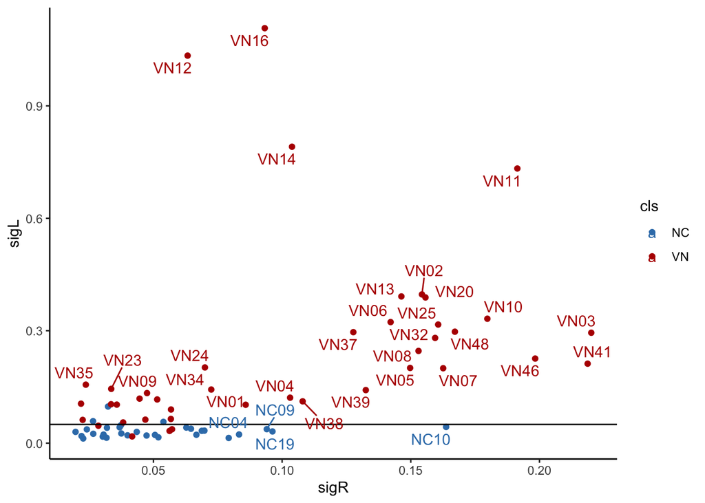

```
[1] "threshold for sigL: 0 ; accuracy: 0.583"
[1] "threshold for sigL: 0.025 ; accuracy: 0.736"
[1] "threshold for sigL: 0.05 ; accuracy: 0.903"
[1] "threshold for sigL: 0.075 ; accuracy: 0.875"
[1] "threshold for sigL: 0.1 ; accuracy: 0.875"
[1] "threshold for sigL: 0.125 ; accuracy: 0.764"
[1] "threshold for sigL: 0.15 ; accuracy: 0.708"
[1] "threshold for sigL: 0.175 ; accuracy: 0.694"
[1] "threshold for sigL: 0.2 ; accuracy: 0.681"
```

### sigL-sigR

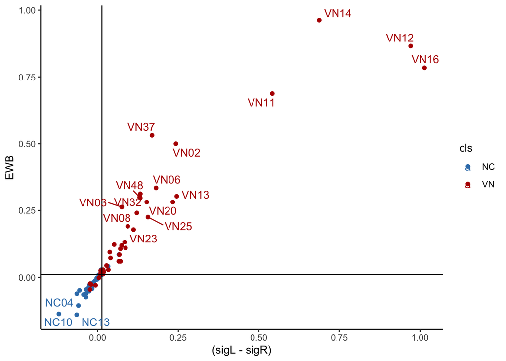

```
[1] "threshold for sigL-sigR: 0 ; accuracy: 0.833"
[1] "threshold for sigL-sigR: 0.006 ; accuracy: 0.847"
[1] "threshold for sigL-sigR: 0.013 ; accuracy: 0.861"
[1] "threshold for sigL-sigR: 0.019 ; accuracy: 0.806"
[1] "threshold for sigL-sigR: 0.025 ; accuracy: 0.806"
[1] "threshold for sigL-sigR: 0.031 ; accuracy: 0.792"
[1] "threshold for sigL-sigR: 0.038 ; accuracy: 0.778"
[1] "threshold for sigL-sigR: 0.044 ; accuracy: 0.764"
[1] "threshold for sigL-sigR: 0.05 ; accuracy: 0.764"
```

### (sigL-sigR)/(sigL+sigR)

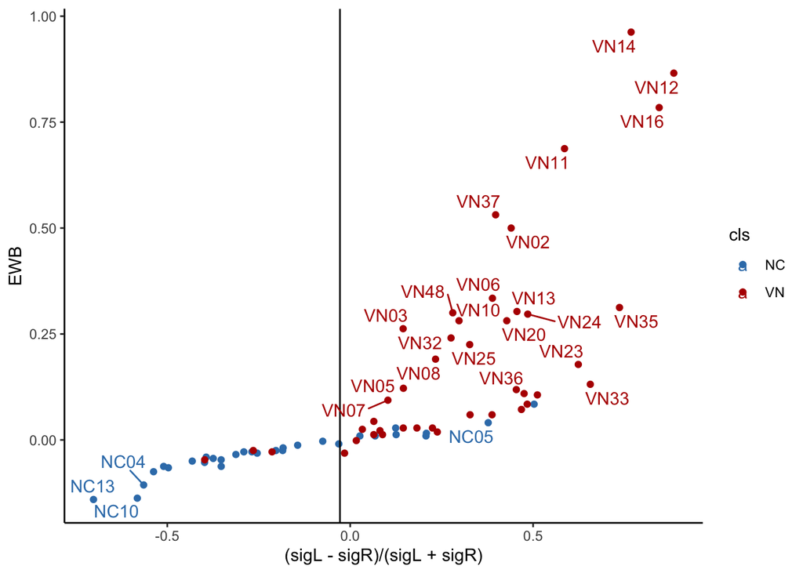

```
[1] "threshold for (sigL-sigR)/(sigL+sigR): -0.04 ; accuracy: 0.833"
[1] "threshold for (sigL-sigR)/(sigL+sigR): -0.034 ; accuracy: 0.833"
[1] "threshold for (sigL-sigR)/(sigL+sigR): -0.028 ; accuracy: 0.847"
[1] "threshold for (sigL-sigR)/(sigL+sigR): -0.021 ; accuracy: 0.847"
[1] "threshold for (sigL-sigR)/(sigL+sigR): -0.015 ; accuracy: 0.833"
[1] "threshold for (sigL-sigR)/(sigL+sigR): -0.009 ; accuracy: 0.833"
[1] "threshold for (sigL-sigR)/(sigL+sigR): -0.002 ; accuracy: 0.833"
[1] "threshold for (sigL-sigR)/(sigL+sigR): 0.004 ; accuracy: 0.833"
[1] "threshold for (sigL-sigR)/(sigL+sigR): 0.01 ; accuracy: 0.833"
```

## Line prior

### Prior and variance

Most people have a prior about the half line length at 0.7 (i.e. 1.4 unit in tatal, or 112 mm). this is quite similar to the lengths of true stimuli: `mean(80,120,120,160)=120mm`

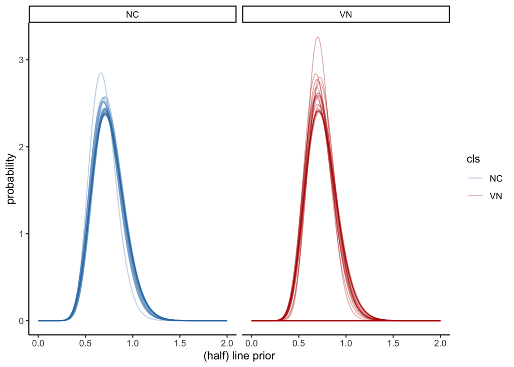

A part of VN had a very small line length prior variance. It means they had a very strong prior, `which explains the cross-over effect`.

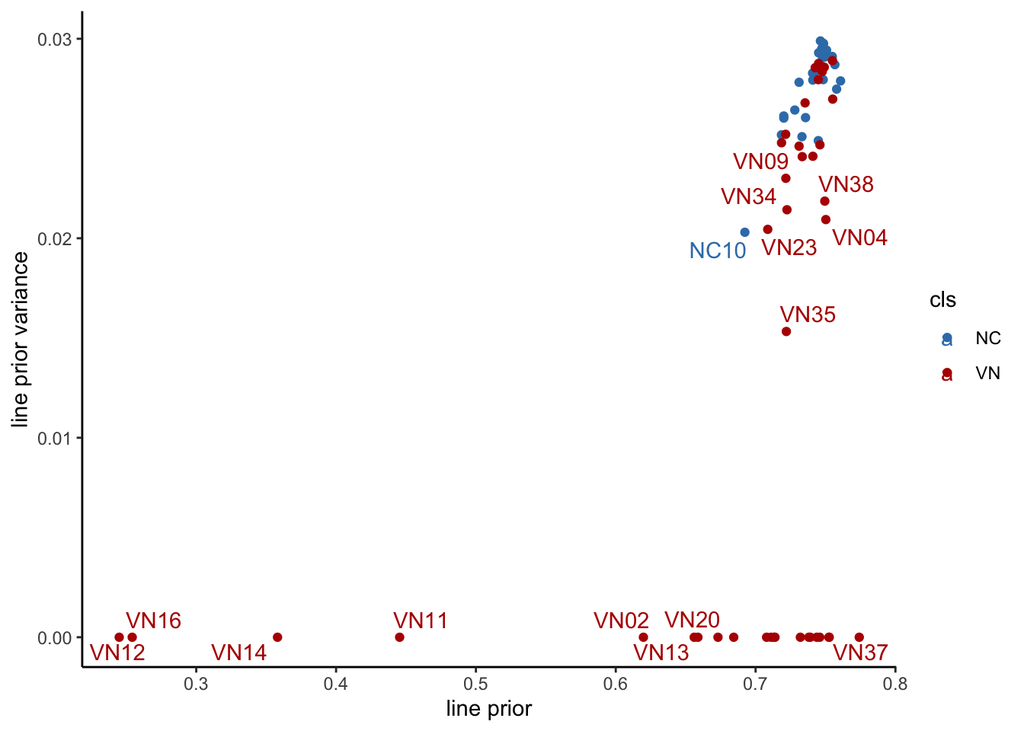

### Variance and sigC

Visualise sigC to check. There are four participants that had very chaotic answers.

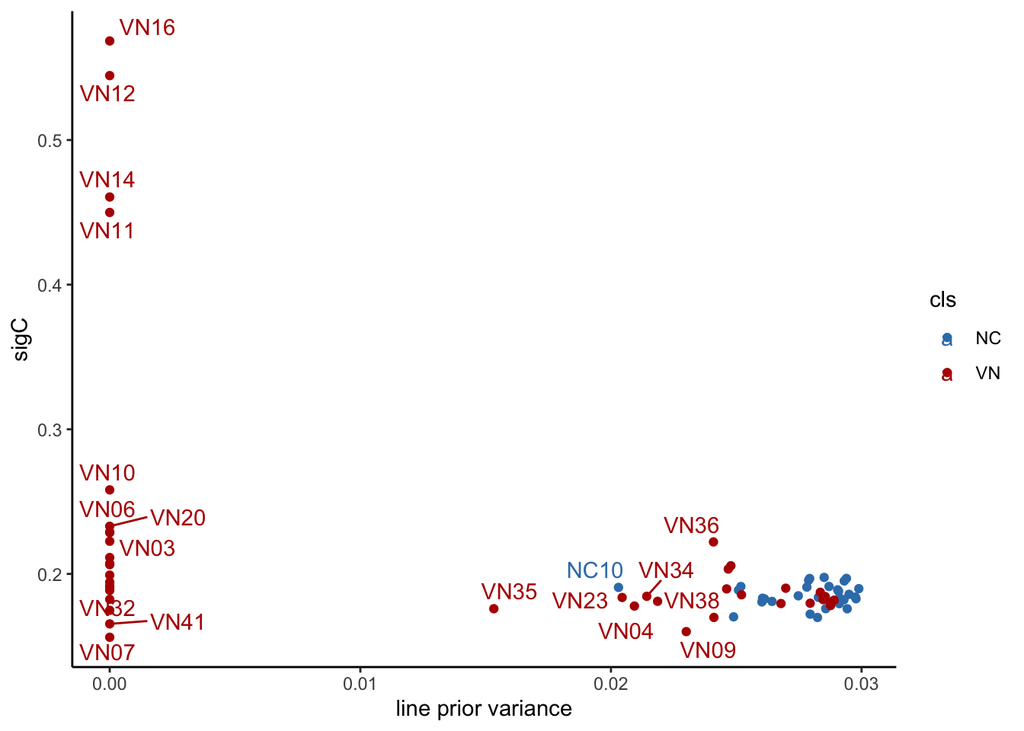

## Classification

Formal classification tasks. We try two classification algorithms: logistic regression (linear), decision tree (non-linear). and use the leave-one-out cross-validation as the procedure.

- predictors: `sigL`, `sigR`, `sigC`, `line_prior`, `line_var`
- indices: `accuracy`, `sensitivity`, `specificity`

|  | predLis | pred | logi_acc | tree_acc | logi_sens | tree_sens | logi_spec | tree_spec |
| --- | --- | --- | --- | --- | --- | --- | --- | --- |
| 1 | 1 | EWB | 0.833 | 0.819 | 0.833 | 0.81 | 0.833 | 0.833 |
| 2 | 2 | LEW | 0.847 | 0.778 | 0.833 | 0.738 | 0.867 | 0.833 |
| 3 | 3 | REW | 0.583 | 0.486 | 0.667 | 0.429 | 0.467 | 0.567 |
| 4 | 4 | EWB+EWS | 0.847 | 0.833 | 0.857 | 0.857 | 0.833 | 0.8 |
| 5 | 5 | sigL | 0.903 | 0.917 | 0.881 | 0.881 | 0.933 | 0.967 |
| 6 | 6 | sigL+sigR | 0.903 | 0.917 | 0.881 | 0.881 | 0.933 | 0.967 |
| 7 | 7 | sigL+sigR+line_prior+line_var | 0.875 | 0.833 | 0.881 | 0.881 | 0.867 | 0.767 |
| 8 | 8 | sigL+sigR+sigC | 0.903 | 0.889 | 0.881 | 0.881 | 0.933 | 0.9 |
| 9 | 9 | sigL+sigR+line_prior+line_var+sigC | 0.889 | 0.847 | 0.881 | 0.929 | 0.9 | 0.733 |
| 10 | 10 | sigL+line_prior | 0.889 | 0.889 | 0.881 | 0.881 | 0.9 | 0.9 |

[output cut: 2 more lines]

Logistic plot:

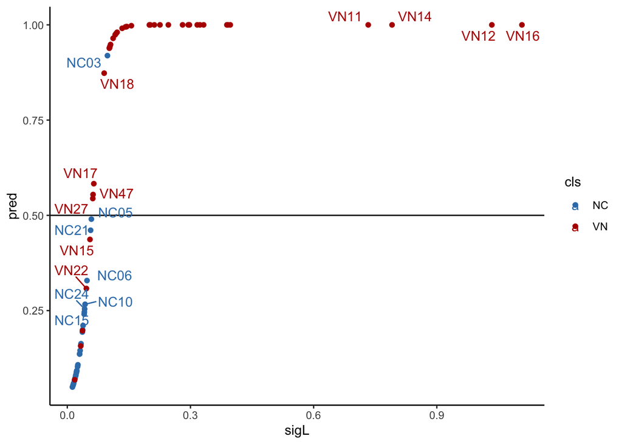

## Only symmetric trials

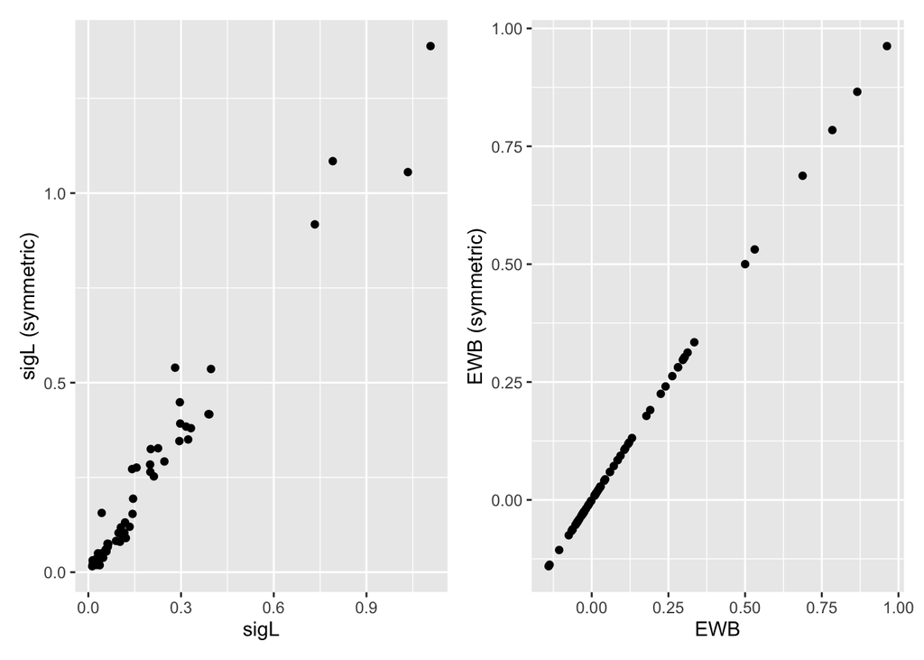

[figure not shown]

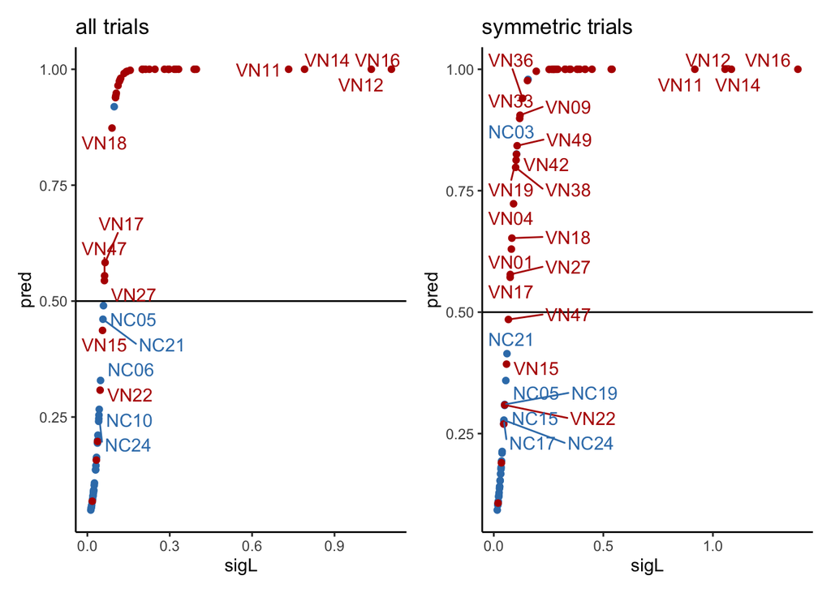

|  | predLis | pred | logi_acc | tree_acc | logi_sens | tree_sens | logi_spec | tree_spec |
| --- | --- | --- | --- | --- | --- | --- | --- | --- |
| 1 | 1 | EWB | 0.833 | 0.833 | 0.833 | 0.833 | 0.833 | 0.833 |
| 2 | 2 | LEW | 0.833 | 0.833 | 0.833 | 0.833 | 0.833 | 0.833 |
| 3 | 3 | sigL | 0.889 | 0.875 | 0.857 | 0.857 | 0.933 | 0.9 |
| 4 | 4 | sigL+sigR | 0.903 | 0.847 | 0.905 | 0.857 | 0.9 | 0.833 |
| 5 | 5 | sigL+sigR+line_prior+line_var | 0.861 | 0.861 | 0.857 | 0.881 | 0.867 | 0.833 |
| 6 | 6 | sigL+sigR+sigC | 0.875 | 0.875 | 0.881 | 0.881 | 0.867 | 0.867 |
| 7 | 7 | sigL+sigR+line_prior+line_var+sigC | 0.861 | 0.861 | 0.857 | 0.881 | 0.867 | 0.833 |
| 8 | 8 | sigL+line_prior | 0.875 | 0.875 | 0.833 | 0.857 | 0.933 | 0.9 |
| 9 | 9 | sigL+line_var | 0.875 | 0.847 | 0.857 | 0.857 | 0.9 | 0.833 |
| 10 | 10 | sigL+line_prior+line_var | 0.847 | 0.875 | 0.833 | 0.905 | 0.867 | 0.833 |